# **Proposal nhóm 2**

# **Danh sách thành viên:**

| STT | Name | MSSV |
| --- | --- | --- |
| 9 | Nguyễn Trí Dũng | 20133029 |
| 10 | Lê Minh Đăng | 20133034 |
| 30 | Nguyễn Khoa Quang Thắng | 20133090 |

# Phần 1: Giới thiệu:

Điện thoại - Vật dụng không thể thiếu trong cuộc sống hiện nay khi mà toàn cầu đang tiến tới công nghệ hóa mọi thứ trong cuộc sống. Với những chức năng đa dạng và ngày càng hiện đại (như soạn văn bản Word, xem phim với độ phân giải cao,…), cộng thêm những chiếc điện thoại ngày nay có khả năng được những thiết bị khác (như máy ảnh, máy nhắn tin, máy ghi âm,…) thì việc càng nhiều người chọn điện thoại là vật bất ly thân là không thể chối cãi.

Nhận thấy điều đó, nhóm 2 nhận thức được rằng việc người mua hàng lựa chọn cấu hình và giá cả khi mua điện thoại luôn được người tiêu dùng đặt lên hàng đầu. Do vậy, để hiểu rõ hơn về sự ảnh hưởng của những chức năng, cấu hình điện thoại tới giá cả, nhóm 2 chọn đề tài là: “Phân tích mô hình dự đoán giá điện thoại qua cấu hình máy”.

Và trong đề tài này, dataset được nhóm 2 thống nhất sử dụng có tên là **Mobile Phone Specifications and Prices** được tải xuống từ Kaggle và tác giả của dataset là **PRATIK** **GARAI.** Theo tác giả, dataset được lấy từ website Gadgets360 - là một trang báo của Ấn Độ được cập nhật các thông tin trên toàn thế giới, dữ liệu từ trang này được scrapped và cleaned bằng cách dùng [code ở đây](https://github.com/PratikGarai/Web-Scrapers/blob/master/BeautifulSoup/Ndtv_Scraper.py) và preprocessed [ở đây](https://github.com/PratikGarai/Mobile-Phone-Dataset-Analysis/blob/master/Additional/ndtv_analysis.ipynb)

[figure not shown]

# **Câu hỏi của nhóm đặt ra:** Dự đoán giá của điện thoại thông qua thông số máy và tìm hiểu biến nào ảnh hưởng tới giá nhiều nhất.

# Phần 2: Dữ liệu:

```r
data<-read.csv("./data.csv")
```

[output not shown]

Với hàm glimpse(), ta biết rằng kích thước của tập dữ liệu là **1359 x 22.**

10 dòng đầu của tập dữ liệu:

```r
head(data,10)
```

```
##    X                           Name   Brand                  Model
## 1  0 OnePlus 7T Pro McLaren Edition OnePlus 7T Pro McLaren Edition
## 2  1                  Realme X2 Pro  Realme                 X2 Pro
## 3  2              iPhone 11 Pro Max   Apple      iPhone 11 Pro Max
## 4  3                      iPhone 11   Apple              iPhone 11
## 5  4                   LG G8X ThinQ      LG              G8X ThinQ
## 6  5                     OnePlus 7T OnePlus                     7T
## 7  6                 OnePlus 7T Pro OnePlus                 7T Pro
## 8  7        Samsung Galaxy Note 10+ Samsung        Galaxy Note 10+
## 9  8               Asus ROG Phone 2    Asus            ROG Phone 2
## 10 9           Xiaomi Redmi K20 Pro  Xiaomi          Redmi K20 Pro
##    Battery.capacity..mAh. Screen.size..inches. Touchscreen Resolution.x
## 1                    4085                 6.67         Yes         1440
## 2                    4000                 6.50         Yes         1080
## 3                    3969                 6.50         Yes         1242
```

[output cut: 40 more lines]

10 dòng cuối của tập dữ liệu:

```r
tail(data,10)
```

```
##         X                        Name     Brand              Model
## 1350 1349          Micromax Bolt D303  Micromax          Bolt D303
## 1351 1350                     Vivo V1      Vivo                 V1
## 1352 1351           Panasonic Eluga Z Panasonic            Eluga Z
## 1353 1352                    Xolo Era      Xolo                Era
## 1354 1353         Intex Aqua Y2 Ultra     Intex      Aqua Y2 Ultra
## 1355 1354               Intex Aqua A2     Intex            Aqua A2
## 1356 1355 Videocon Infinium Z51 Nova+  Videocon Infinium Z51 Nova+
## 1357 1356               Intex Aqua Y4     Intex            Aqua Y4
## 1358 1357             iBall Andi4 B20     iBall          Andi4 B20
## 1359 1358         iBall Andi Avonte 5     iBall      Andi Avonte 5
##      Battery.capacity..mAh. Screen.size..inches. Touchscreen Resolution.x
## 1350                   1300                  4.0         Yes          480
## 1351                   2300                  5.0         Yes          720
## 1352                   2050                  5.0         Yes          720
```

[output cut: 40 more lines]

# Phần 3: Kế hoạch phân tích dữ liệu:

### 1. Các biến kết quả (phản hồi, Y) và dự đoán (giải thích, X):

#### **Biến dự đoán(giải thích):**

- Name
- Brand
- Model
- Battery capacity (mAh)
- Screen size (inches)
- Touchscreen
- Resolution x
- Resolution y
- Processor
- RAM (MB)
- Internal storage (GB)
- Rear camera
- Front camera
- Operating system
- Wi-Fi
- Bluetooth
- GPS
- Number of SIMs
- 3G,4G/ LTE

#### **Biến kết quả (phản hồi):**

- Price

### 2) Phân tích dữ liệu sơ bộ:

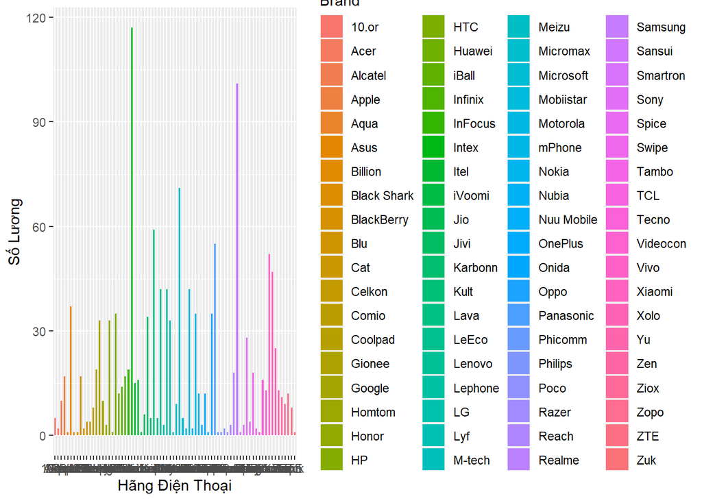

```r
ggplot(data = data) +
  geom_bar(mapping = aes(x = Brand, fill = Brand), width = 0.5)+
  labs(
    x = "Hãng Điện Thoại",
    y = "Số Lương")
```

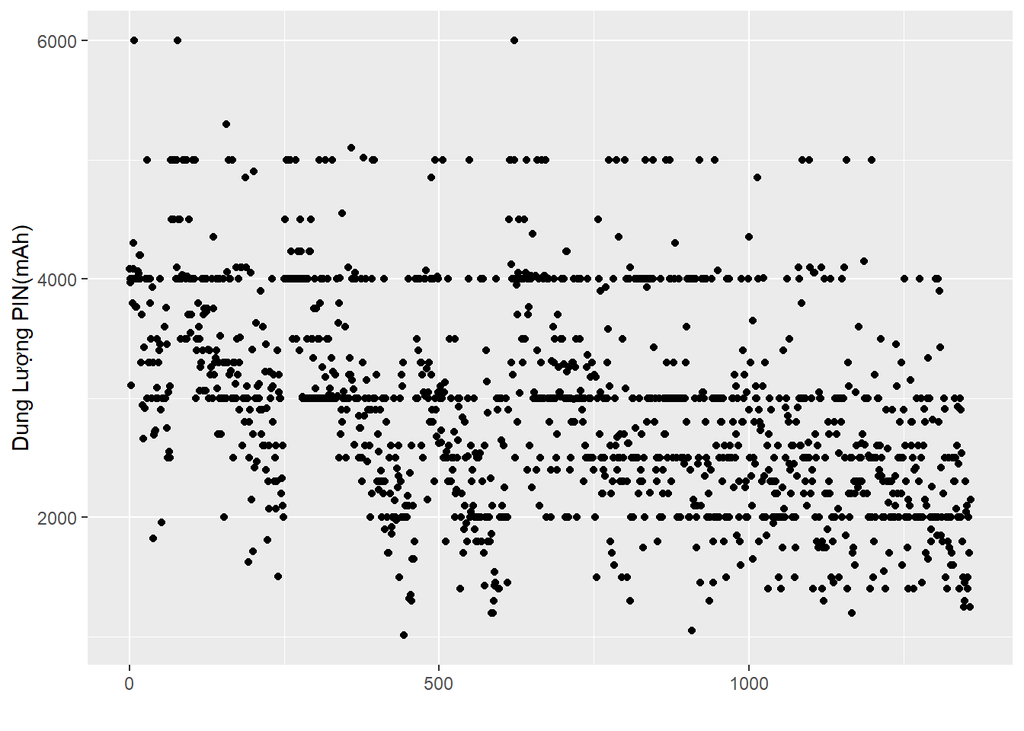

```r
ggplot(data = data, mapping = aes(x = X, y = Battery.capacity..mAh.)) +
  geom_point() +
  labs(
    x = "",
    y = "Dung Lượng PIN(mAh)")
```

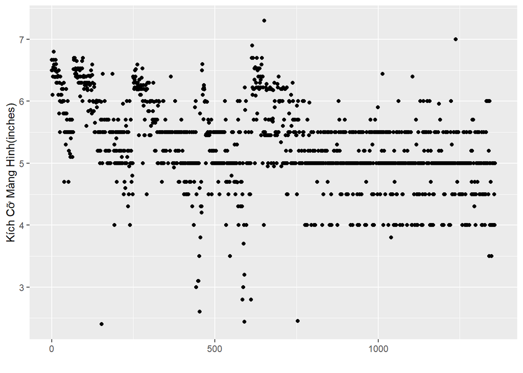

```r
ggplot(data = data, mapping = aes(x = X, y = Screen.size..inches.)) +
  geom_point() +
  labs(
    x = "",
    y = "Kích Cỡ Màng Hình(inches)")
```

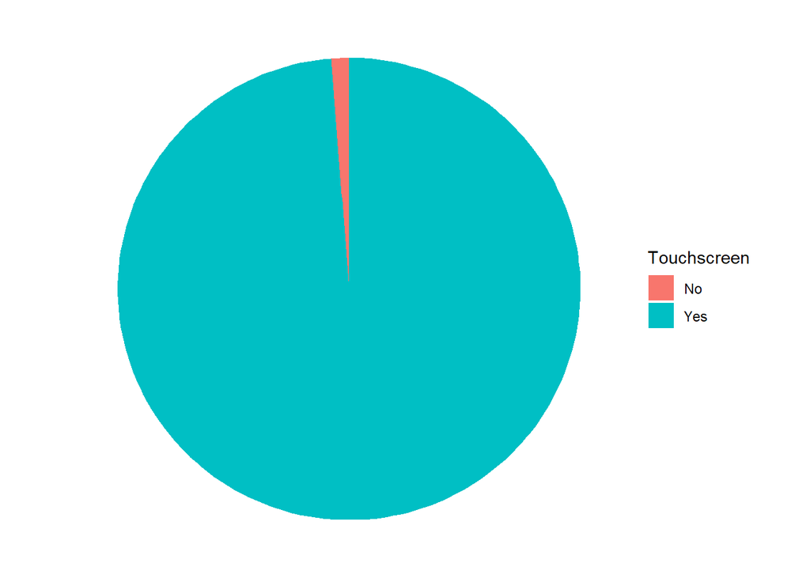

```r
data %>%
  select(Touchscreen) %>%
  group_by(Touchscreen) %>%
  count() %>%
  ggplot(aes(x="", y=n, fill=Touchscreen)) +
  geom_bar(stat="identity", width=1) +
  coord_polar("y", start=0) +
  theme_void()
```

[figure not shown]

```r
ggplot(data = data) +
  geom_bar(mapping = aes(x = Touchscreen), width = 1, color = "blue") +
  labs(
    x = "Resolution X",
    y = "Số Lương")
```

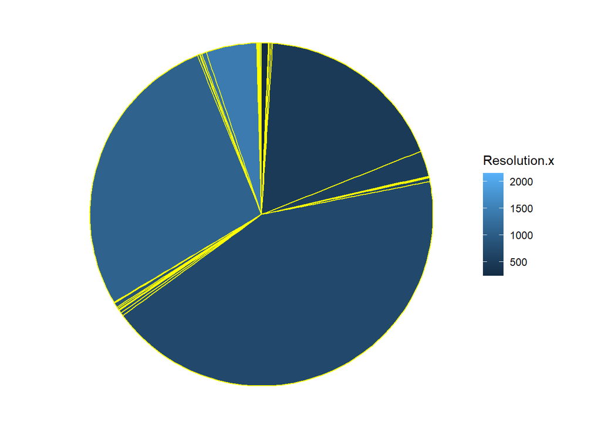

```r
data %>%
  select(Resolution.x) %>%
  group_by(Resolution.x) %>%
  count() %>%
  ggplot(aes(x="", y=n, fill=Resolution.x)) +
  geom_bar(stat="identity", width=1, color = "yellow") +
  coord_polar("y", start=0) +
  theme_void()
```

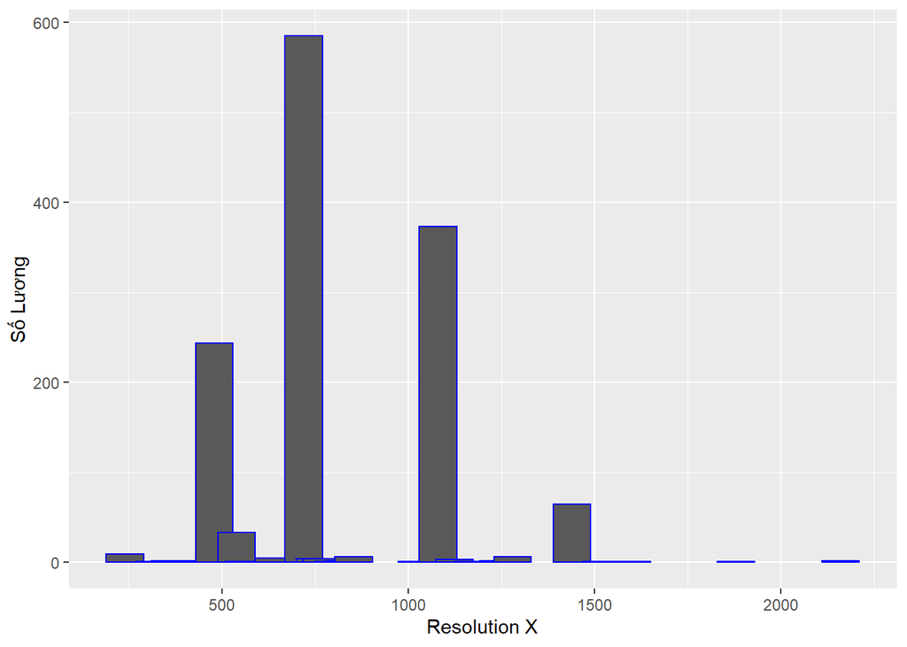

```r
ggplot(data = data) +
  geom_bar(mapping = aes(x = Resolution.x), width = 100, color = "blue") +
  labs(
    x = "Resolution X",
    y = "Số Lương")
```

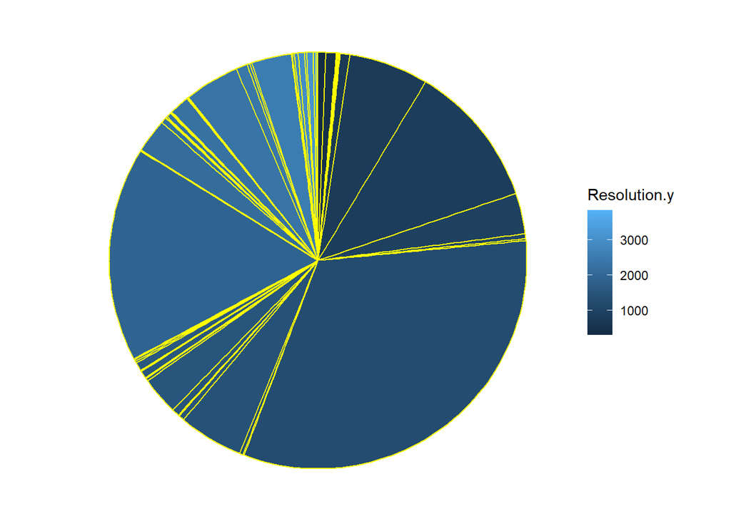

```r
data %>%
  select(Resolution.y) %>%
  group_by(Resolution.y) %>%
  count() %>%
  ggplot(aes(x="", y=n, fill=Resolution.y)) +
  geom_bar(stat="identity", width=1, color = "yellow") +
  coord_polar("y", start=0) +
  theme_void()
```

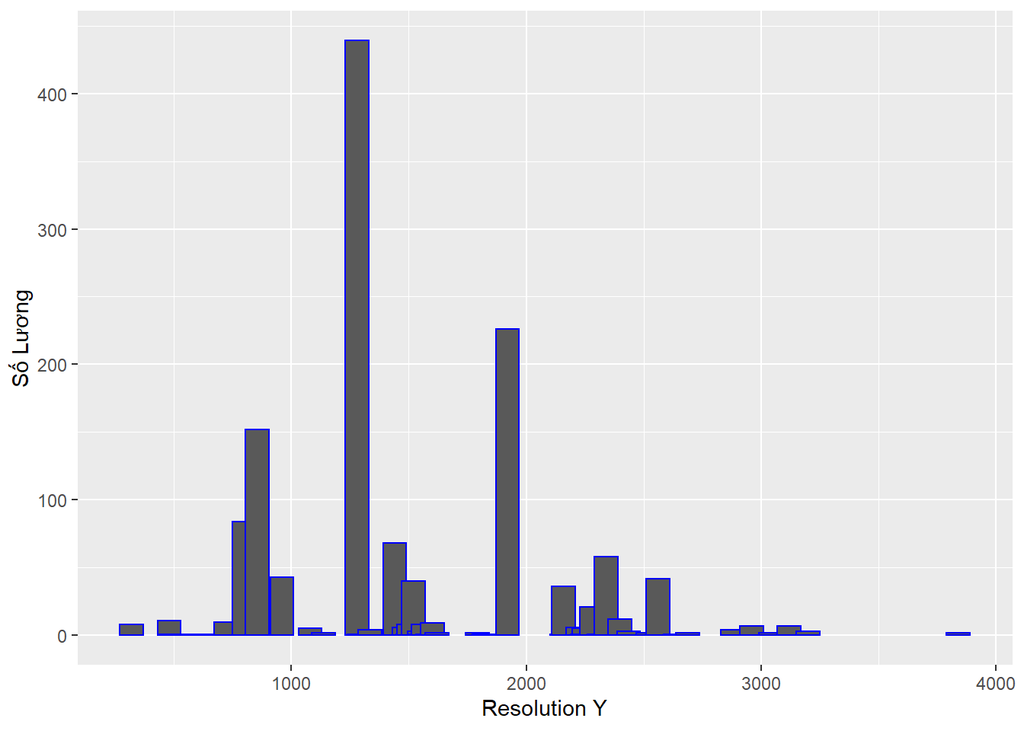

```r
ggplot(data = data) +
  geom_bar(mapping = aes(x = Resolution.y), width = 100, color = "blue") +
  labs(
    x = "Resolution Y",
    y = "Số Lương")
```

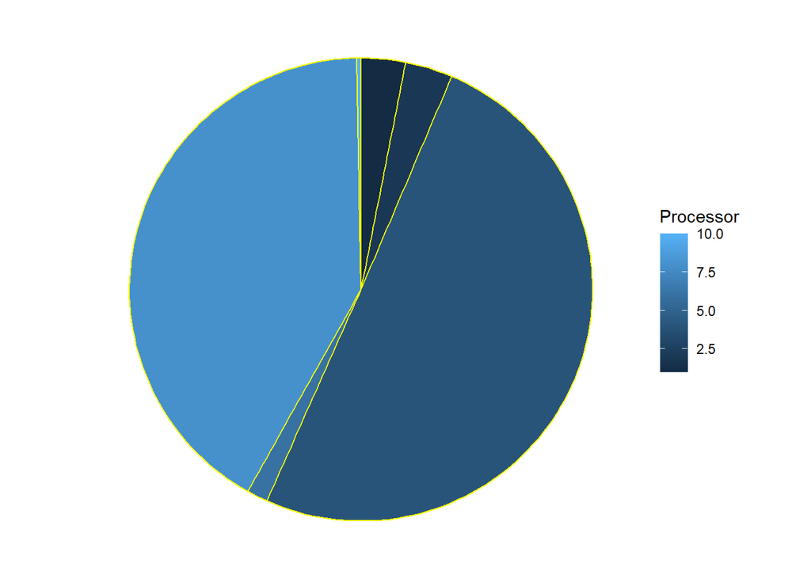

```r
data %>%
  select(Processor) %>%
  group_by(Processor) %>%
  count() %>%
  ggplot(aes(x="", y=n, fill=Processor)) +
  geom_bar(stat="identity", width=1, color = "yellow") +
  coord_polar("y", start=0) +
  theme_void()
```

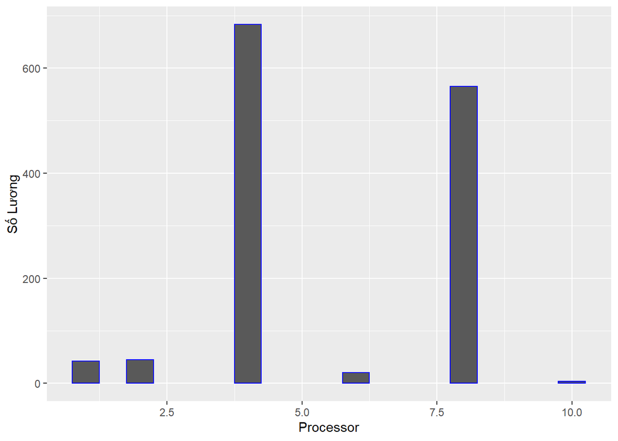

```r
ggplot(data = data) +
  geom_bar(mapping = aes(x = Processor), width = 0.5, color = "blue") +
  labs(
    x = "Processor",
    y = "Số Lương")
```

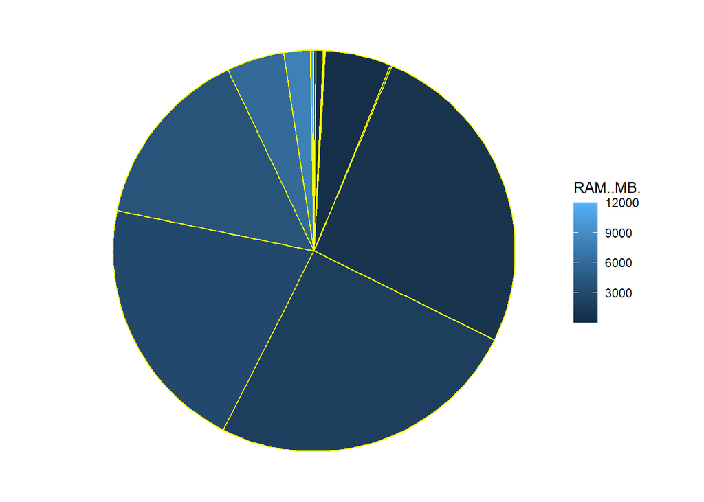

```r
data %>%
  select(RAM..MB.) %>%
  group_by(RAM..MB.) %>%
  count() %>%
  ggplot(aes(x="", y=n, fill=RAM..MB.)) +
  geom_bar(stat="identity", width=1000, color = "yellow") +
  coord_polar("y", start=0) +
  theme_void()
```

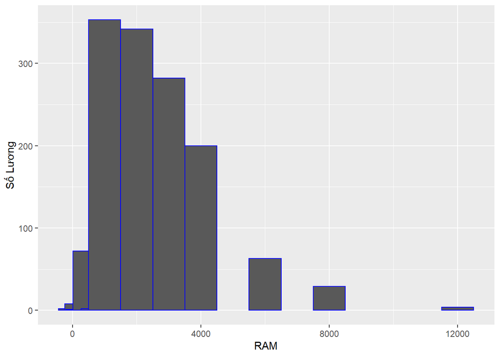

```r
ggplot(data = data) +
  geom_bar(mapping = aes(x = RAM..MB.), width = 1000, color = "blue") +
  labs(
    x = "RAM",
    y = "Số Lương")
```

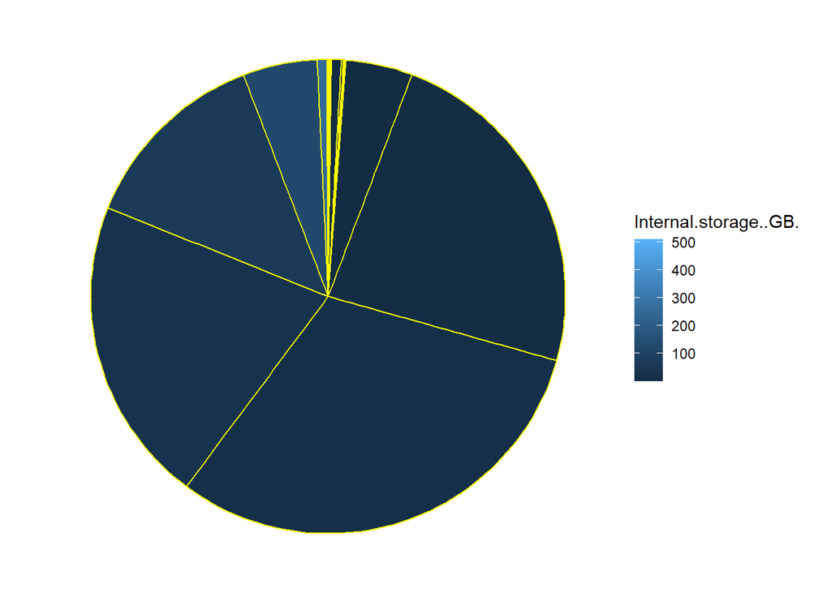

```r
data %>%
  select(Internal.storage..GB.) %>%
  group_by(Internal.storage..GB.) %>%
  count() %>%
  ggplot(aes(x="", y=n, fill=Internal.storage..GB.)) +
  geom_bar(stat="identity", width=64, color = "yellow") +
  coord_polar("y", start=0) +
  theme_void()
```

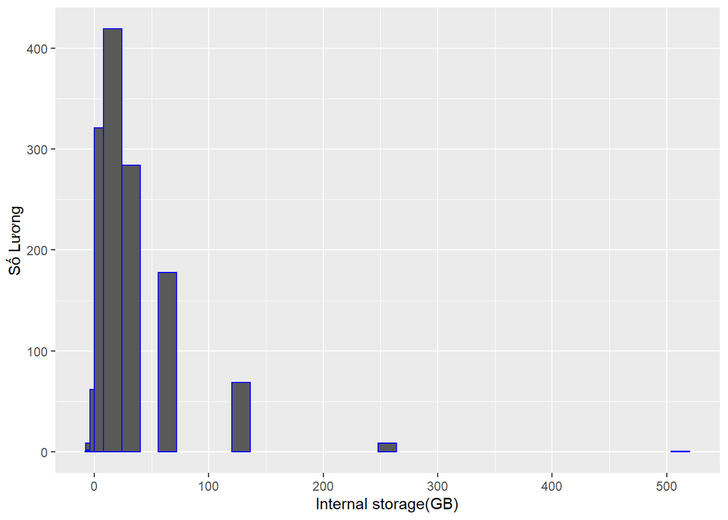

```r
ggplot(data = data) +
  geom_bar(mapping = aes(x = Internal.storage..GB.), width = 16, color = "blue") +
  labs(
    x = "Internal storage(GB)",
    y = "Số Lương")
```

[output not shown]

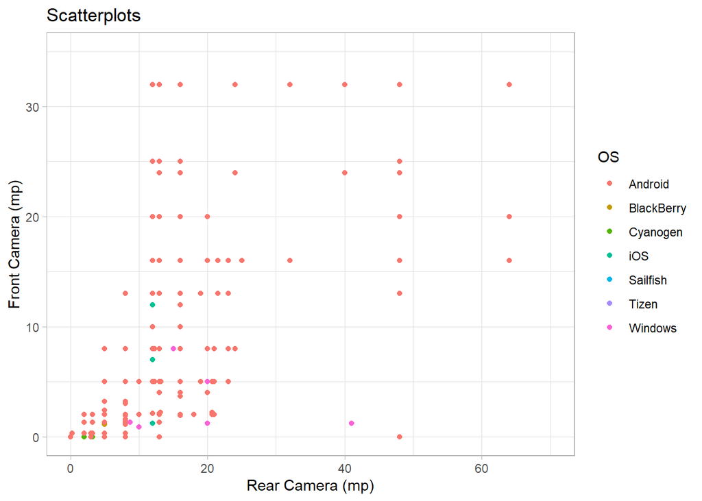

```r
ggplot(data = data, mapping = aes(x = Rear.camera, y = Front.camera)) +
  geom_point(mapping = aes(color = Operating.system), size = 1.5) +
  xlim(0,70) + ylim(0,35) +
  xlab('Rear Camera (mp)') +
  ylab('Front Camera (mp)') +
  ggtitle(label = 'Scatterplots') +
  scale_color_brewer(palette = "Set1") +
  theme_light() +
  scale_color_discrete(name = "OS")
```

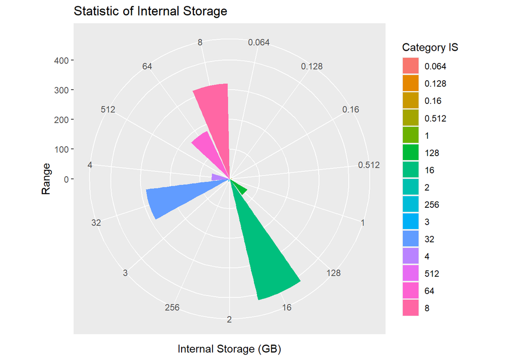

```r
data1 <- data
data1$Internal.storage..GB.<- as.character(data1$Internal.storage..GB.)


ggplot() +
  geom_bar(data = data1,mapping = aes(x = Internal.storage..GB., fill =                    Internal.storage..GB.)) +
  coord_polar() +
  xlab('Internal Storage (GB)') +
  ylab('Range') +
  ggtitle(label = 'Statistic of Internal Storage') +

  scale_fill_discrete(name = "Category IS")
```

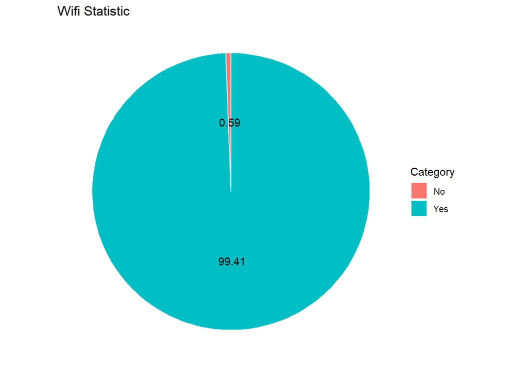

```r
data2 <- data.frame(
  group = c("Yes","No"),
  value = c((sum(data$Wi.Fi == "Yes")-sum(data$Wi.Fi == "No"))/sum(data$Wi.Fi == "Yes")*100,sum(data$Wi.Fi == "No")/sum(data$Wi.Fi == "Yes")*100)
)

ggplot(data = data2, aes(x = "", y = value, fill = group)) +
  geom_col(color = "white") +
  geom_text(aes(label = (round(value, digits = 2))),
            position = position_stack(vjust = 0.5)) +
  coord_polar(theta = "y") +
  theme_void() +
  ggtitle(label = 'Wifi Statistic') +
  scale_fill_discrete(name = "Category")
```

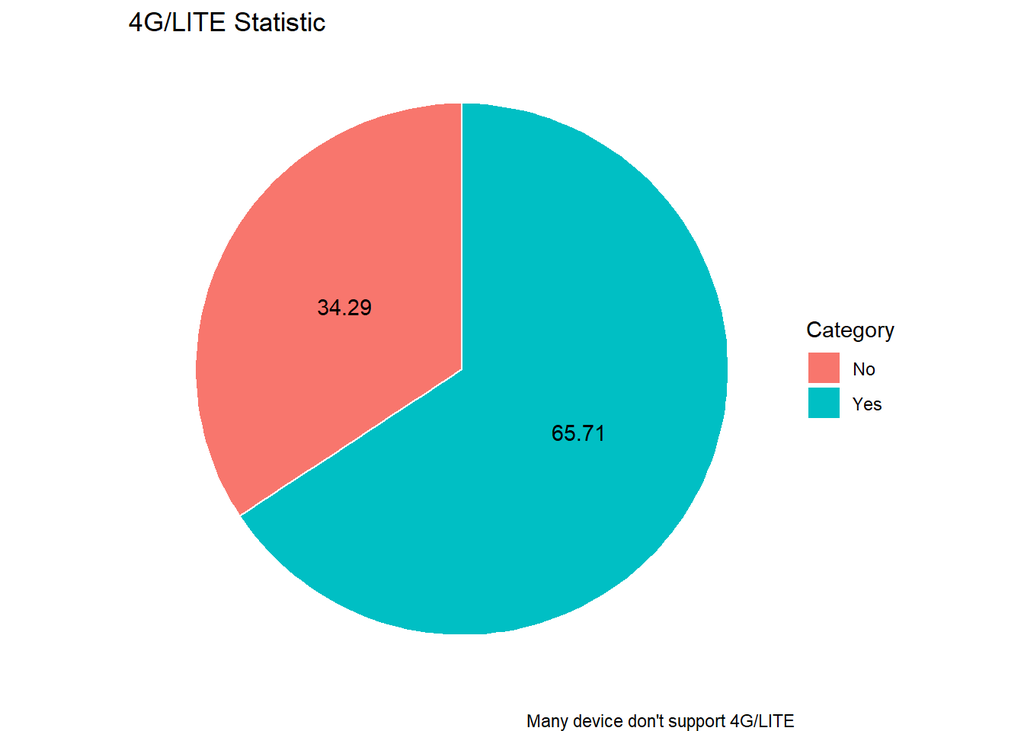

```r
data3 <- data.frame(
  group = c("Yes","No"),
  value = c((sum(data$X4G..LTE == "Yes")-sum(data$X4G..LTE == "No"))/sum(data$X4G..LTE == "Yes")*100,sum(data$X4G..LTE == "No")/sum(data$X4G..LTE == "Yes")*100)
)

ggplot(data = data3, aes(x = "", y = value, fill = group)) +
  geom_col(color = "white") +
  geom_text(aes(label = (round(value, digits = 2))),
            position = position_stack(vjust = 0.5)) +
  coord_polar(theta = "y") +
  theme_void() +
  labs(title = '4G/LITE Statistic', caption = "Many device don't support 4G/LITE") +
  scale_fill_discrete(name = "Category")
```

### **3) Các phương pháp mà nhóm tin rằng sẽ giúp trả lời cho câu hỏi đặt ra:**

Xây dựng mô hình dự đoán biến kết quả là giá của điện thoại dựa trên các biến dự đoán.

### **4) Kế hoạch thực hiện và phân công công việc:**

Kế hoạch thực hiện:

Hiện tại, tiếp tục nghiên cứu, tìm hiểu về mô hình regression.

Hoàn thành Milestone trước 27/11/2022

Làm Presentation và report trước 11/12/2022

Phân công công việc:

| STT | MSSV | Họ và Tên | Phân công |
| --- | --- | --- | --- |
| 09 | 20133029 | Nguyễn Trí Dũng | Kiểm kê giả thuyết + Mô hình dự đoán |
| 30 | 20133090 | Nguyễn Khoa Quang Thắng | EDA + Mô hình dự đoán |
| 10 | 20133034 | Lê Minh Đăng | EDA |